# Statistics in Python: Two One-Sided t-Test (TOST)

⇦ Back

The TOST can be used to test **equivalence**: do the means of two populations differ by less than a given amount?

- In reality, we don’t *actually* use the means of two population because, of course, it’s (usually) not practical to measure every member of an entire population. For this reason we take a **sample** from each and compare the means of those.
- These populations and samples should be **independent** of each other: a change in one of them should not affect any of the others
- We assume that the values in the populations are **normally distributed**

The test was originally published by Donald J Schuirmann (not Donald **L** Schuirmann as appears in the [R](https://www.rdocumentation.org/packages/equivalence/versions/0.7.2/topics/tost.stat) and [Pingouin](https://pingouin-stats.org/generated/pingouin.tost.html) documentation):

- Schuirmann, Donald J. On hypothesis testing to determine if the mean of a normal distribution is contained in a known interval. Biometrics. 1981;37:617
- Schuirmann, Donald J. A comparison of the two one-sided tests procedure and the power approach for assessing the equivalence of average bioavailability. Journal of Pharmacokinetics and Biopharmaceutics. 1987;15(6):657–680. DOI: 10.1007/BF01068419.

# 1 Statistical Hypotheses

At first glance, a research question such as “do the means of two populations differ by less than a given amount?” suggests the following pair of hypotheses:

- $H_0:\ \mu_x - \mu_y \geq \delta$
- $H_1:\ \mu_x - \mu_y \lt \delta$

where $\mu_x$ and $\mu_y$ are the means of the two populations and $\delta$ is the tolerance you’ve decided on. However, we need to remember that we can’t assume that $\mu_x$ is larger than $\mu_y$, and so the difference between them (if one exists) might be negative! We thus need to have a second set of hypotheses to cover this possibility:

- $H_0:\ \mu_x - \mu_y \leq -\delta$
- $H_1:\ \mu_x - \mu_y \gt -\delta$

This is why it’s called the **two** one-sided t-test: the fact that you have two pairs of hypotheses means that you need to do the one-sided t-test **twice**. It is also why, ultimately, you only choose the result of one of these t-tests as your final answer: it’s because you only care about the one where the difference between the means has the same sign as $\delta$.

# 2 Example One: Pingouin

This comes from [the documentation](https://pingouin-stats.org/generated/pingouin.tost.html) for Pingouin’s `tost()` function. Here’s the example data:

```python
# Example data
a = [4, 7, 8, 6, 3, 2]
b = [6, 8, 7, 10, 11, 9]
```

## 2.1 Doing it with Pingouin

Pingouin can be installed from the terminal with `python3.10 -m pip install pingouin` (replace `3.10` with whichever version of Python you have installed). This gives you access to the `tost()` function which, as the name suggests, performs the TOST.

As mentioned, the TOST asks “do the means of two populations differ by less than a given amount?”. This given amount is called the ‘bound’ and, by default, Pingouin gives it a value of 1.

```python
import pingouin as pg

pval = pg.tost(a, b).loc['TOST', 'pval']

print(f'TOST: p = {pval:.3f}')
```

```
## TOST: p = 0.965
```

If you’re interested in seeing exactly what this function is doing in the background, you can take a look at [the source code](https://github.com/raphaelvallat/pingouin/blob/master/pingouin/equivalence.py).

If you see a message saying `OutdatedPackageWarning: The package pingouin is out of date.` it means you need to update (upgrade) Pingouin. Do this from the terminal with `python3.10 -m pip install pingouin --upgrade`.

## 2.2 Doing it with SciPy

While SciPy doesn’t have a dedicated TOST function, it does have the t-test. So we can use that twice in its ‘one-sided’ configuration. Specifically, we’re using the unpaired (independent) two-sample t-test:

```python
from scipy import stats
import numpy as np

#
# TOST
#
# Magnitude of region of similarity
bound = 1
# Unpaired two-sample t-test
_, p_greater = stats.ttest_ind(np.array(a) + bound, b, alternative='greater')
_, p_less = stats.ttest_ind(np.array(a) - bound, b, alternative='less')
# Choose the maximum p-value
pval = max(p_less, p_greater)

print(f'TOST: p = {pval:5.3f}')
```

```
## TOST: p = 0.965
```

As expected, this gives us the same answer as Pingouin.

SciPy and Numpy can be installed from the terminal with:

- `python3.10 -m pip install scipy`
- `python3.10 -m pip install numpy`

where `python3.10` is the version of Python you have installed.

## 2.3 Doing it Explicitly

To see what is going on in the background in more detail, here’s the same result obtained in more steps:

```python
# Sample means
mean_a = np.mean(a)
mean_b = np.mean(b)
# Sample sizes
sample_size_a = len(a)
sample_size_b = len(b)
# Sample variances
var_a = np.var(a, ddof=1)
var_b = np.var(b, ddof=1)
# Pooled sample variance (ie we assume equal variances)
var_p = ((sample_size_a - 1) * var_a + (sample_size_b - 1) * var_b) / (sample_size_a + sample_size_b - 2)
# Pooled sample standard deviation
std_p = np.sqrt(var_p)
# t-Values
bound = 1
t_1 = (mean_a - mean_b + bound) / np.sqrt(var_p / sample_size_a + var_p / sample_size_b)
t_2 = (mean_a - mean_b - bound) / np.sqrt(var_p / sample_size_a + var_p / sample_size_b)
# Degrees of freedom
dof = sample_size_a + sample_size_b - 2
# Critical values of the t distribution
alpha_1 = 0.05
t_crit_1 = stats.t.ppf(1 - alpha_1, dof)
alpha_2 = 1 - alpha_1
t_crit_2 = stats.t.ppf(1 - alpha_2, dof)
# Test the t-statistics against the t-values required for significance
if (t_1 > t_crit_1) and (t_2 < t_crit_2):
    print('Reject both null hypotheses; the means of the two samples are equivalent')
else:
    print('Fail to reject both null hypotheses; the means of the two samples are not equivalent')
```

```
## Fail to reject both null hypotheses; the means of the two samples are not equivalent
```

# 3 Example Two: Real Statistics

This example comes from [here](https://www.real-statistics.com/students-t-distribution/equivalence-testing-tost/) and uses this data:

```python
import pandas as pd

data = {
    'values': [
        2311, 2274, 2262, 2297, 2291, 2319, 2263, 2329, 2289, 2287, 2290, 2301,
        2298, 2260, 2250, 2242, 2302, 2297, 2293, 2286, 2270, 2313, 2327, 2290,
    ],
    'types': ['original'] * 12 + ['new'] * 12
}
df = pd.DataFrame(data)
```

Pandas can be installed from the terminal with `python3.10 -m pip install pandas`

## 3.1 Summary Statistics

Here’s how to replicate the values in the top table of Figure 1 in [the example](https://www.real-statistics.com/students-t-distribution/equivalence-testing-tost/):

```python
# Initialise the summary table
summary = pd.DataFrame()

# Count
n = df.groupby('types').count()
summary['Count'] = n['values']
# Mean
summary['Mean'] = df.groupby('types').mean()['values']
# Variance
summary['Variance'] = df.groupby('types').var()['values']

print(summary.round(2))
```

```
##           Count     Mean  Variance
## types
## new          12  2285.67    650.79
## original     12  2292.75    423.84
```

```python
# Difference of the means
diff_mean = df.groupby('types').mean().diff().values[1][0]
print(f'Difference of the means = {diff_mean:.3f}')
```

```
## Difference of the means = 7.083
```

```python
# Mean variance
mean_var = df.groupby('types').var().mean().values[0]
print(f'Mean variance = {mean_var:.3f}')
```

```
## Mean variance = 537.314
```

```python
# Cohen's d
cohens_d = diff_mean / np.sqrt(mean_var)
print(f"Cohen's d = {cohens_d:.3f}")
```

```
## Cohen's d = 0.306
```

## 3.2 t-Test: Equal Variances

Here’s how to replicate the values in the middle table of Figure 1 in [the example](https://www.real-statistics.com/students-t-distribution/equivalence-testing-tost/):

```python
# Standard deviations
std = df.groupby('types').std(ddof=1)
# Standard errors of the means
sem = std / np.sqrt(df.groupby('types').mean())
# Standard error of the difference of the means
sed = np.sqrt(std['values']['new']**2 / n['values']['new'] + std['values']['original']**2 / n['values']['original'])

print(f'Standard error of the difference of the means = {sed:.3f}')
```

```
## Standard error of the difference of the means = 9.463
```

```python
# Degrees of freedom
dof = n.sum() - 2
print(f"Degrees of freedom = {dof['values']}")
```

```
## Degrees of freedom = 22
```

Now it’s time to do the t-tests. Let’s re-configure the raw data so it’s slightly easier to work with:

```python
# Data frame to dictionary
dct = df.groupby('types')['values'].apply(list).to_dict()
# Data
x = dct['original']
y = dct['new']
```

The example we’re following does both a one-tailed and a two-tailed test, where the one-tailed test has a bound of 0 (which they call the ‘hyp mean’ or ‘hypothetical difference of the means’) and an alternative hypothesis of ‘greater’:

```python
# One-sided unpaired two-sample t-test
bound = 0
t_greater, p_greater = stats.ttest_ind(np.array(x) + bound, y, alternative='greater')

print(f't-stat = {t_greater:.3f}; p-value = {p_greater:.3f}')
```

```
## t-stat = 0.749; p-value = 0.231
```

```python
# Two-sided unpaired two-sample t-test
bound = 0
t_stat, pval = stats.ttest_ind(x, y, alternative='two-sided')

print(f't-stat = {t_stat:.3f}; p-value = {pval:.3f}')
```

```
## t-stat = 0.749; p-value = 0.462
```

If we use a significance level of 0.1, here are the critical t-values we would need to reach in order to get significance:

```python
# Significance level
alpha = 0.1
# Percent-point function (aka quantile function) of the t-distribution
t_crit_one = stats.t.ppf(1 - alpha, dof)[0]
print(f't-crit (one-tailed): {t_crit_one:.3f}')
```

```
## t-crit (one-tailed): 1.321
```

```python
# Percent-point function (aka quantile function) of the t-distribution
t_crit_two = stats.t.ppf(1 - (alpha / 2), dof)[0]
print(f't-crit (two-tailed): {t_crit_two:.3f}')
```

```
## t-crit (two-tailed): 1.717
```

Now for the confidence interval for the difference of the means (the fact that we’re finding an interval that extends *both* sides of the difference of the means implies we need to use the critical t-value from the *two-sided* test):

```python
# Margin of error
d = t_crit_two * sed
# Confidence interval
ci_upper = diff_mean + d
ci_lower = diff_mean - d

print(f'Difference of the means = {diff_mean:.3f} 95% CI [{ci_lower:.3f}, {ci_upper:.3f}]')
```

```
## Difference of the means = 7.083 95% CI [-9.166, 23.333]
```

## 3.3 Final Answer

[The example](https://www.real-statistics.com/students-t-distribution/equivalence-testing-tost/) only shows one one-sided t-test for equal variances in Figure 1, which is only one-half of the full TOST. Here’s the full thing with a bound of 25:

```python
#
# TOST
#
# Magnitude of region of similarity
bound = 25
# Unpaired two-sample t-test
_, p_greater = stats.ttest_ind(np.array(x) + bound, y, alternative='greater')
_, p_less = stats.ttest_ind(np.array(x) - bound, y, alternative='less')
# Choose the maximum p-value
pval = max(p_less, p_greater)

print(f'TOST: p = {pval:5.3f}')
```

```
## TOST: p = 0.036
```

Here it is with Pingouin:

```python
pval = pg.tost(x, y, bound=25).loc['TOST', 'pval']

print(f'TOST: p = {pval:.3f}')
```

```
## TOST: p = 0.036
```

This p-value of 0.036 matches that obtained in the example (although this isn’t shown in the figure, it’s in the text).

## 3.4 Doing it Explicitly

Once again, here’s the same result obtained in more steps:

```python
# Sample
a = [2311, 2274, 2262, 2297, 2291, 2319, 2263, 2329, 2289, 2287, 2290, 2301]
b = [2298, 2260, 2250, 2242, 2302, 2297, 2293, 2286, 2270, 2313, 2327, 2290]

# Sample means
mean_a = np.mean(a)
mean_b = np.mean(b)
# Sample sizes
sample_size_a = len(a)
sample_size_b = len(b)
# Sample variances
var_a = np.var(a, ddof=1)
var_b = np.var(b, ddof=1)
# Pooled sample variance (ie we assume equal variances)
var_p = ((sample_size_a - 1) * var_a + (sample_size_b - 1) * var_b) / (sample_size_a + sample_size_b - 2)
# Pooled sample standard deviation
std_p = np.sqrt(var_p)
# t-Values
bound = 25
t_1 = (mean_a - mean_b + bound) / np.sqrt(var_p / sample_size_a + var_p / sample_size_b)
t_2 = (mean_a - mean_b - bound) / np.sqrt(var_p / sample_size_a + var_p / sample_size_b)
# Degrees of freedom
dof = sample_size_a + sample_size_b - 2
# Critical values of the t distribution
alpha_1 = 0.05
t_crit_1 = stats.t.ppf(1 - alpha_1, dof)
alpha_2 = 1 - alpha_1
t_crit_2 = stats.t.ppf(1 - alpha_2, dof)
# Test the t-statistics against the t-values required for significance
if (t_1 > t_crit_1) and (t_2 < t_crit_2):
    print('Reject both null hypotheses; the means of the two samples are equivalent')
else:
    print('Fail to reject both null hypotheses; the means of the two samples are not equivalent')
```

```
## Reject both null hypotheses; the means of the two samples are equivalent
```

# 4 Power Calculations

A function that finds the power of the TOST is as follows:

```python
import numpy as np
from scipy import stats


def tost_power(n, alpha, delta, cv):
    """Calculate the power of a TOST."""
    mt1 = -(delta * np.sqrt(n)) / cv
    mt2 = (delta * np.sqrt(n)) / cv
    ta = stats.t.ppf(1 - alpha, df=n - 1)
    power = stats.t.cdf(mt2 - ta, df=n-1) - stats.t.cdf(mt1 + ta, df=n-1)
    # Change negative values for power to 0
    try:
        power[power < 0] = 0
    except TypeError:
        pass

    return power
```

This function takes the following parameters:

- `n` - the sample size (which can be a range of numbers)
- `alpha` - the significance level, aka the sensitivity of the test
- `delta` - the ‘acceptance region’, ‘bound’ or ‘magnitude of region of similarity’
- `cv` - the coefficient of variation

If we choose the following values for the constants (in practice these would be estimated by looking at existing data):

```python
# Significance level/sensitivity of the test
alpha = 0.05
# Acceptance region/bound/magnitude of region of similarity
delta = 0.1  # 10%
# Coefficient of variation
cv = 0.08
```

…then we can calculate the power of the test for a sample size of 2 to 30 participants:

```python
# Sample size
n = np.arange(2, 31)
# Run the test
print(tost_power(n, alpha, delta, cv))
```

```
## [0.         0.         0.10728153 0.4565518  0.65687185 0.77848563
##  0.85518797 0.90464045 0.93693518 0.95818703 0.97223697 0.98155173
##  0.98773743 0.99184895 0.99458294 0.99640109 0.99761002 0.99841363
##  0.99894759 0.99930221 0.99953761 0.99969377 0.99979731 0.99986592
##  0.99991136 0.99994143 0.99996132 0.99997447 0.99998316]
```

This is easier to visualise in a graph:

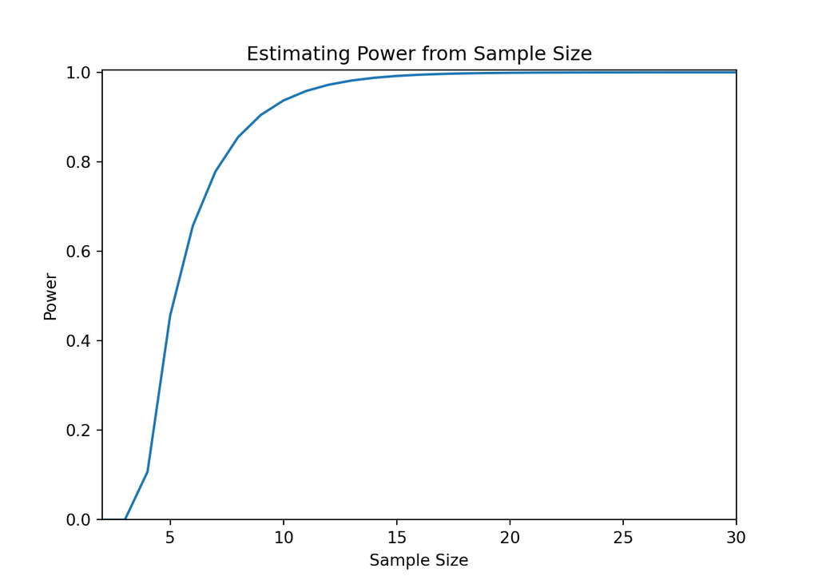

```python
import matplotlib.pyplot as plt

plt.plot(n, tost_power(n, alpha, delta, cv))
plt.title('Estimating Power from Sample Size')
plt.ylabel('Power')
plt.xlabel('Sample Size')
plt.ylim(0, 1.005)
plt.xlim(2, 30)
```

Of course, the reverse question is usually more important: how many participants do I need for my study to achieve a certain power? If you want a power of 0.8, here’s how to use Scipy’s optimize module - specifically the routine known as ‘Brent’s method’ - to calculate that:

```python
from scipy import optimize


def func(n):
    """Generate a residual to minimise."""
    res = tost_power(n, alpha, delta, cv) - desired_power

    return res


# Desired power for your study
desired_power = 0.8  # 80%
# Give a range of sample sizes in which the optimiser can search
min_guess = 2
max_guess = 100
# Find the number of participants that gives the desired power level
sol = optimize.brentq(func, min_guess, max_guess)
print(sol)
```

```
## 7.238280195222553
```

So we would need 8 participants for this level of power.

⇦ Back